# CORRELAÇÃO EM R

by Edneide Ramalho

5/30/2021

Fonte: https://www.r-bloggers.com/2021/05/correlation-in-r-na-friendliness-accepting-matrix-as-input-data-returning-p-values-visualization-and-pearson-vs-spearman/?utm_source=feedburner&utm_medium=email&utm_campaign=Feed%3A+RBloggers+%28R+bloggers%29

Muitas vezes necessitamos comaprar diferentes variáveis numéricas, e estudar se estas são linearmente dependentes. Estas informações também podem nos auxiliar a detectar covariáveis e definir fórmulas que se ajustem aos efeitos impostos por estas covariáveis. Temos os métodos de Pearson e de postos de Spearman.

Primeiro, vamos construir uma matriz 10x5 e prrenchê-la com 10 posições aleatórias.

```r
# Matriz
dat <- matrix(rnorm(50), nrow=10, ncol=5)
```

- Susbstituindo 10 valores por NA na matriz:

```r
set.seed(877)
naInd <- sample(1:length(dat), 10)
dat[naInd] <- NA
```

```r
colnames(dat) <- paste0("col", 1:ncol(dat))
rownames(dat) <- paste0("row", 1:nrow(dat))
```

Vamos definir uma função de correlação que retornará os coeficientes de correlação e os p-valores:

```r
mycor <- function(x, ...){
  r <- apply(x, 2, function(j){
    apply(x, 2, function(i){
      as.numeric(cor.test(i,j, ...)$estimate)
    })
  })
  P <- apply(x, 2, function(j){
    apply(x, 2, function(i){
      as.numeric(cor.test(i, j,...)$p.value)
    })
  })
  out <- c()
  out$P <- P
  out$r <- r
  return(out)
}
```

- Rodando a função na matriz `dat`:

```r
time1 <- Sys.time()
myCorDat <- mycor(dat, method="pearson", na.action=na.omit)
time2 <- Sys.time()
```

```r
# Run time
runTimeMyCor <- difftime(time2, time1)
runTimeMyCor
```

```
## Time difference of 0.03340697 secs
```

```r
# Result
myCorDat
```

```
## $P
##           col1      col2      col3      col4      col5
## col1 0.0000000 0.3886802 0.4360058 0.2472278 0.8594062
## col2 0.3886802 0.0000000 0.8667716 0.3739623 0.3431484
## col3 0.4360058 0.8667716 0.0000000 0.1603754 0.2047596
## col4 0.2472278 0.3739623 0.1603754 0.0000000 0.3936288
## col5 0.8594062 0.3431484 0.2047596 0.3936288 0.0000000
##
## $r
##             col1       col2       col3       col4        col5
## col1  1.00000000  0.4349805  0.3968256 -0.5054184  0.08310328
## col2  0.43498050  1.0000000 -0.1048296 -0.3999783 -0.47322629
## col3  0.39682560 -0.1048296  1.0000000  0.5931647 -0.60338615
## col4 -0.50541840 -0.3999783  0.5931647  1.0000000 -0.38508820
## col5  0.08310328 -0.4732263 -0.6033861 -0.3850882  1.00000000
```

**OBS.:** Ler sobre o pacote `Hmisc`.

```r
library(Hmisc)
time1 <- Sys.time()
rcorrDat <- Hmisc::rcorr(dat, type="pearson")
time2 <- Sys.time()
(runTimeRcorr <-  difftime(time2, time1))
```

```
## Time difference of 0.002146006 secs
```

```r
rcorrDat
```

```
##       col1  col2  col3  col4  col5
## col1  1.00  0.43  0.40 -0.51  0.08
## col2  0.43  1.00 -0.10 -0.40 -0.47
## col3  0.40 -0.10  1.00  0.59 -0.60
## col4 -0.51 -0.40  0.59  1.00 -0.39
## col5  0.08 -0.47 -0.60 -0.39  1.00
##
## n
##      col1 col2 col3 col4 col5
## col1    8    6    6    7    7
## col2    6    8    5    7    6
## col3    6    5    7    7    6
## col4    7    7    7    9    7
## col5    7    6    6    7    8
##
## P
##      col1   col2   col3   col4   col5
## col1        0.3887 0.4360 0.2472 0.8594
## col2 0.3887        0.8668 0.3740 0.3431
## col3 0.4360 0.8668        0.1604 0.2048
## col4 0.2472 0.3740 0.1604        0.3936
## col5 0.8594 0.3431 0.2048 0.3936
```

# Gráfico de correlação

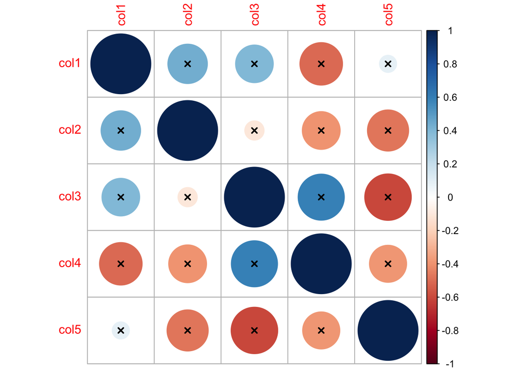

```r
library(corrplot)
# jpeg("corplotTest.jpg", width=800,
#      height=800,
#      quality=100,
#      pointsize = 24)
corrplot(cor=myCorDat$r,
         p.mat=myCorDat$P,
         type="full", insig="pch", sig.level=.1,
         pch.cex=.9)
```

```r
# dev.off()
```

Os x`s no gráfico mostram correlações **não significativas**. Note que o nível de sginificância foi de 10% (0.1), um pouco mais ralaxado do que o usual 5% (0.05).

# Pearson vs. Spearman

A correlação de Spearman, que é um acorrelação de postos (ranking) é mais utilizada para dados assimétricos e com outliers nos dados e detecta correlações fortes entre variáveis x e y.

```r
# Defining an unskewed data
x<- 1:50
# Defining a highly skewed data
y<-exp(x)

e1071::skewness(x)
```

```
## [1] 0
```

```r
#[1] 0
e1071::skewness(y)
```

```
## [1] 5.574573
```

```r
#[1] 5.574573

cor.test(x=x, y=y, method="pearson")
```

```
##
##  Pearson's product-moment correlation
##
## data:  x and y
## t = 2.6098, df = 48, p-value = 0.01205
## alternative hypothesis: true correlation is not equal to 0
## 95 percent confidence interval:
##  0.08223784 0.57449344
## sample estimates:
##       cor
## 0.3525162
```

```r
cor.test(x=x, y=y, method="spearman")
```

```
##
##  Spearman's rank correlation rho
##
## data:  x and y
## S = 0, p-value < 2.2e-16
## alternative hypothesis: true rho is not equal to 0
## sample estimates:
## rho
##   1
```

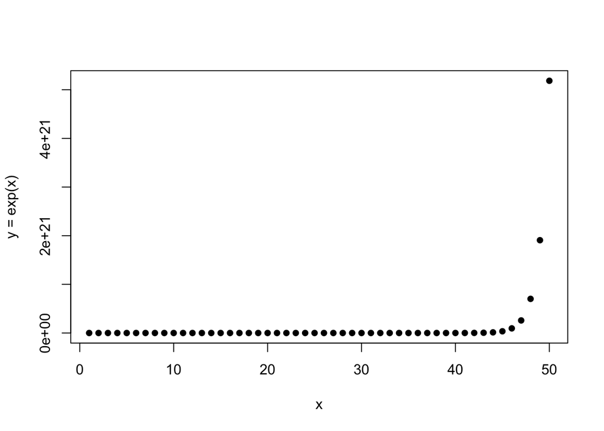

```r
plot(x, y, pch=16, xlab="x", ylab="y = exp(x)")
```